# Andreasens Nursery Research Visit Kemps Creek and Mangrove Mtn

Hawkesbury Institute for the Environment Research Team

May 23-27 2016

### Research Visit Summary

With the help of several staff at Andreasens Nursery we measured Size Index on 1116 conforming trees. This included 20 tree species/varieties across 10 different container sizes. Container volumes covered the entire spectrum of the AS2303 Size Index range. We assessed 53 total batches from the Kemps Creek and Mangrove Mountain sites combined. Due to the large amount of available stock we capped measurements to 20 trees per batch for larger sizes and 45 trees per batch for smaller sizes. The research visit was completed in a total of 4 days. Using a staging area, the above and belowground visual assessments were quickly completed for all tree stock in containers up to 45L. Larger containers were then assessed by visiting individual tree stock batches within the nursery. One tree was initially assessed for each batch. If this tree failed (e.g.. J-rooting, circling) then the option was given to the nursery to assess additional trees. Measurements of Size Index variables and categorical shape parameters were completed for all batches that passed the above and belowground testing process.

### How do the assessed tree stock at Andreasens Nursery fit in the range of Size Index values specified in AS2303? Each color represents a different tree species/variety

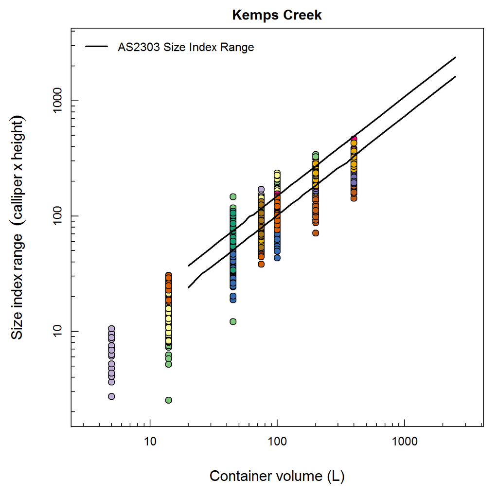

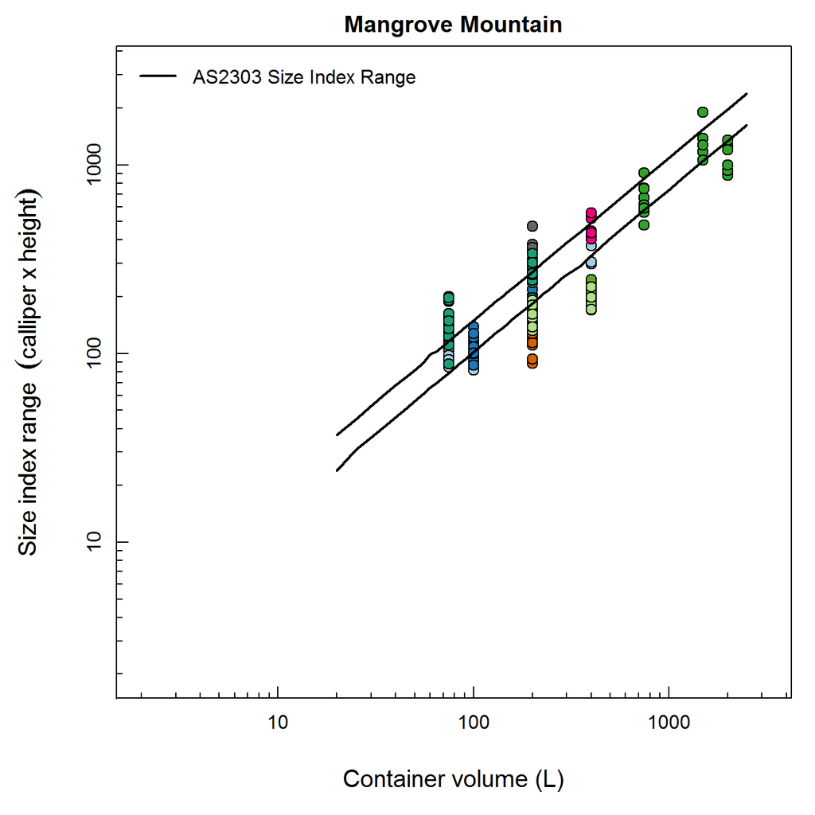

#### Subset of species available in multiple sizes

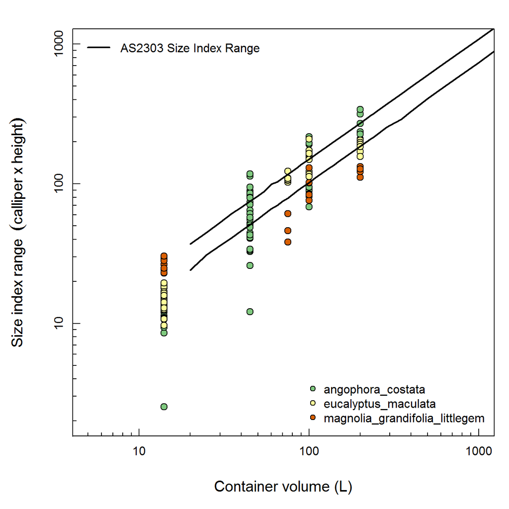

### Height and calliper @ 300mm are postively correlated, as expected. The data which stick out are the large Ficus trees from mangrove mountain (1500 and 2000L) with vastly different trunk structures.

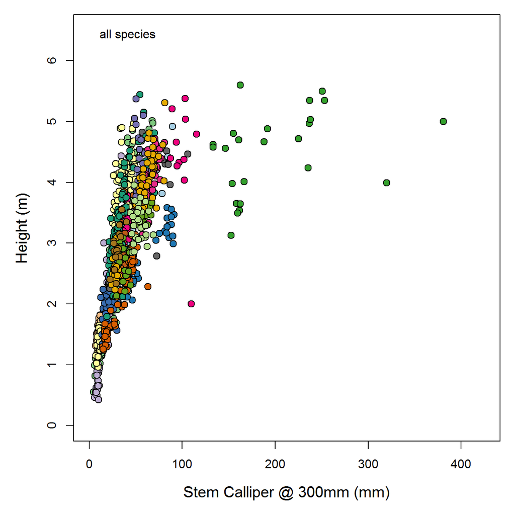

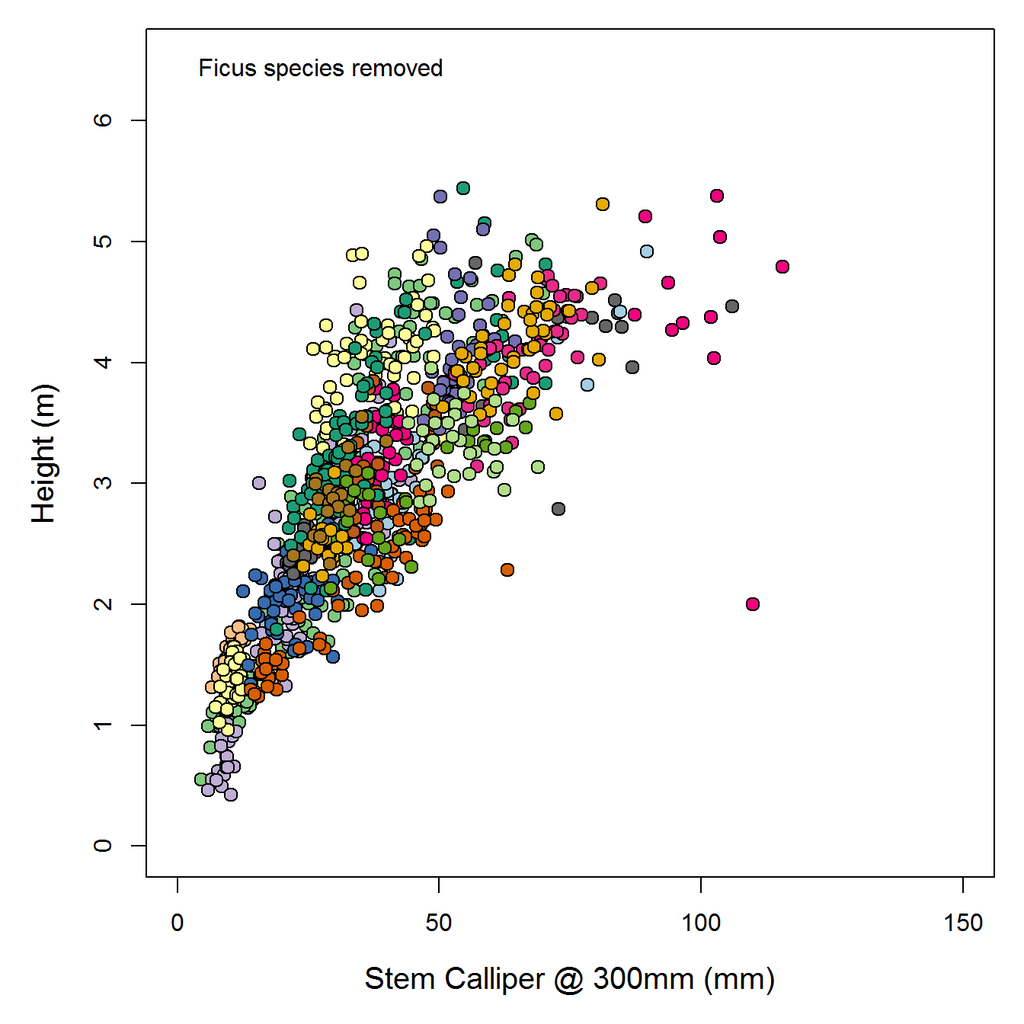

### Is variation in Size Index driven by either height or calliper?

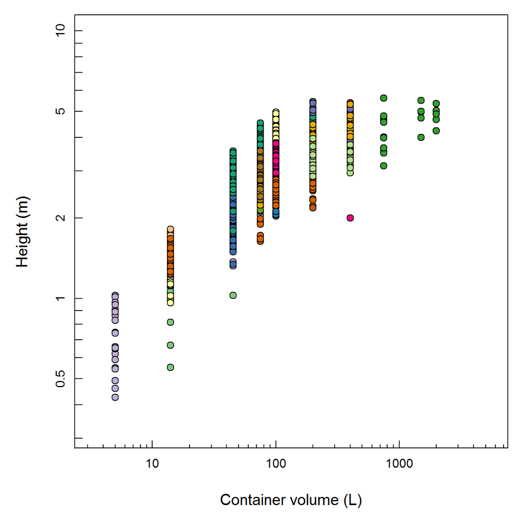

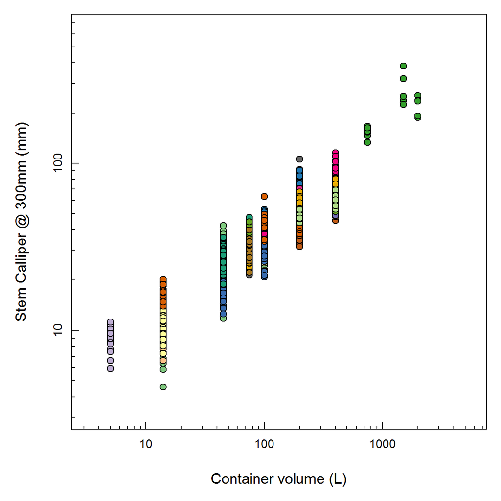

### The Ficus species fit well with AS2303, despite variable trunk anatomy. This provides a nice example of how the Size Index parameter in AS2303 is intended to work. It would be very difficult to create a single parameter index (e.g. calliper) with container volume for some species, like Ficus, with highly variable trunk forms.

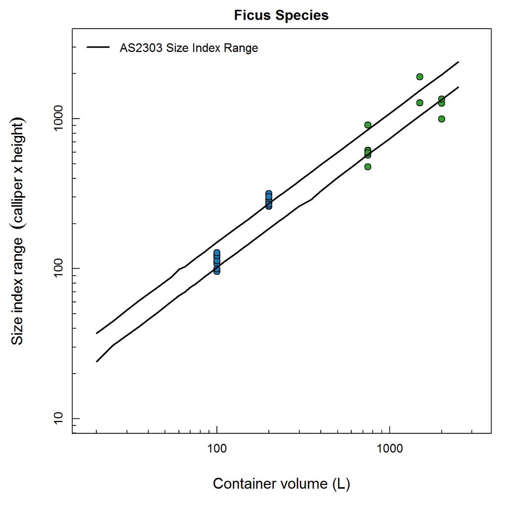

### List of the tree stock we were able to measure

| species | site | volume |
| --- | --- | --- |
| angophora_costata | Kemps Creek | 14 |
| angophora_costata | Kemps Creek | 45 |
| angophora_costata | Kemps Creek | 100 |
| angophora_costata | Kemps Creek | 200 |
| banksia_integrifolia | Kemps Creek | 5 |
| banksia_integrifolia | Kemps Creek | 45 |
| banksia_integrifolia | Kemps Creek | 75 |
| banksia_integrifolia | Kemps Creek | 100 |
| eucalyptus citriodora | Kemps Creek | 14 |
| eucalyptus_maculata | Kemps Creek | 14 |
| eucalyptus_maculata | Kemps Creek | 75 |
| eucalyptus_maculata | Kemps Creek | 100 |
| eucalyptus_maculata | Kemps Creek | 200 |
| eucalyptus_sideroxylon | Kemps Creek | 45 |
| eucalyptus_sideroxylon | Kemps Creek | 100 |
| jacaranda_mimosifolia | Kemps Creek | 75 |
| jacaranda_mimosifolia | Kemps Creek | 100 |
| jacaranda_mimosifolia | Kemps Creek | 400 |
| jacaranda_mimosifolia | Mangrove Mountain | 400 |
| lagerstroemia_indicaxfaurei_natchez | Kemps Creek | 200 |
| lagerstroemia_indicaxfaurei_natchez | Kemps Creek | 400 |
| lagerstroemia_indicaxfaurei_sioux | Kemps Creek | 75 |
| lagerstroemia_indicaxfaurei_sioux | Kemps Creek | 200 |
| lophostemon_confertus | Kemps Creek | 45 |
| lophostemon_confertus | Mangrove Mountain | 75 |
| lophostemon_confertus | Mangrove Mountain | 200 |
| magnolia_grandifolia_littlegem | Kemps Creek | 14 |
| magnolia_grandifolia_littlegem | Kemps Creek | 75 |
| magnolia_grandifolia_littlegem | Kemps Creek | 100 |
| magnolia_grandifolia_littlegem | Mangrove Mountain | 200 |
| plantus_hybrida_acerifolia | Kemps Creek | 200 |
| plantus_hybrida_acerifolia | Kemps Creek | 400 |
| pyrus_calleryana_chanticleer | Kemps Creek | 200 |
| pyrus_calleryana_chanticleer | Kemps Creek | 400 |
| tristaniopsis_laurina_luscious | Kemps Creek | 75 |
| tristaniopsis_laurina_luscious | Mangrove Mountain | 400 |
| ulmus_parvifolia_todd | Kemps Creek | 75 |
| ulmus_parvifolia_todd | Kemps Creek | 200 |
| ulmus_parvifolia_todd | Kemps Creek | 400 |
| waterhousea_floribunda_greenavenue | Kemps Creek | 75 |
| araucaria_heterophylla | Mangrove Mountain | 200 |
| elaeocarpus_reticulatus_primadonna | Mangrove Mountain | 75 |
| elaeocarpus_reticulatus_primadonna | Mangrove Mountain | 100 |
| elaeocarpus_reticulatus_primadonna | Mangrove Mountain | 400 |
| ficus_macrocarpa_flash | Mangrove Mountain | 100 |
| ficus_macrocarpa_flash | Mangrove Mountain | 200 |
| ficus_rubiginosa | Mangrove Mountain | 750 |
| ficus_rubiginosa | Mangrove Mountain | 1500 |
| ficus_rubiginosa | Mangrove Mountain | 2000 |
| waterhousia_floribunda_ameroo | Mangrove Mountain | 200 |
| waterhousia_floribunda_ameroo | Mangrove Mountain | 400 |